# Experiment 2

Kenny Smith and Jennifer Culbertson

06/08/2020

# Introduction

Data analysis for Experiment 2.

Experiment 2 input language: 60% SOV, 40% case, OSV (50% case) marked more than SOV (33% case).

# Load the data.

```r
exp2Data <- read.csv('../RawData/exp2Data.csv')

#at some point we switched terminology in the paper from Agents Can/Cannot be Patients to Subjects Can/Cannot Be Objects - need to correct this throughout
exp2Data$EventType <- revalue(exp2Data$EventType,
                              c("Agents Cannot Be Patients"="Subjects Cannot Be Objects",
                                "Agents Can Be Patients"="Subjects Can Be Objects"))

#it will be useful to have Subjects Cannot Be Objects as baseline
exp2Data$EventType <- relevel(as.factor(exp2Data$EventType),ref='Subjects Cannot Be Objects')

#day needs to be a factor for the stats
exp2Data$Day <- as.factor(exp2Data$Day)
```

# Counts of participants and participant exclusions per day

```r
#got this from https://stackoverflow.com/questions/12840294/counting-unique-distinct-values-by-group-in-a-data-frame
exp2.counts.table <- plyr::ddply(exp2Data,~Day,summarise,N=length(unique(workerId)))
exp2.counts.table
```

```
##   Day   N
## 1   1 114
## 2   2  90
## 3   3  88
## 4   4  81
```

```r
exp2.scores.by.block <- aggregate(score~workerId+Day+Block,data=exp2Data,FUN=mean)
exp2.failed.noun.comprehension <- subset(exp2.scores.by.block,Block=='NounComprehension2' & score<0.7)
exp2.failed.sentence.comprehension <- subset(exp2.scores.by.block,Block=='SentenceComprehension1' & score<0.7)
ddply(exp2.failed.sentence.comprehension,~Day,summarise,N_excluded=length(unique(workerId)))
```

```
##   Day N_excluded
## 1   1          3
## 2   3          1
```

# Counts of grammatical/ungrammatical trials

Including these so we can see how they were calculated.

```r
aggregate(grammatical~Day,FUN=mean,data=subset(exp2Data,Block=="SentenceTest1"))
```

```
##   Day grammatical
## 1   2   0.7311111
## 2   3   0.8721264
## 3   4   0.8861111
```

```r
rejection.counts <- ddply(subset(exp2Data,Block=="SentenceTest1" & grammatical==0),~wordorder,summarise,N=length(unique(workerId)))
#ordered list of rejection types - not printng in interests of space
rejection.counts <- rejection.counts[order(-rejection.counts$N),]
#rejection.counts
```

# Results

## Identification accuracy on comprehension trials

Using text annotations for people at ceiling, but note that has a slightly weird effect when *everyone* is at ceiling - there is no dot so the dots can change alignment. Could be fixed by adding a single dot at 100% but frankly figuring out how to do this makes me want to cry.

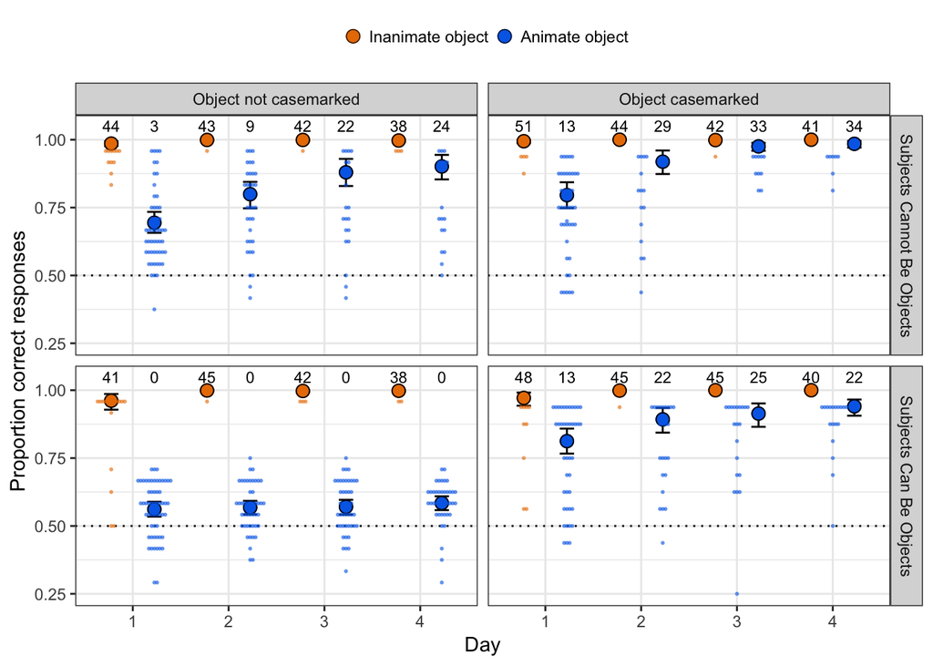

This is singular.

```r
exp2.score.model.1 <- glmer(score~casemarked * Day * EventType + (1 | workerId) + (0 + casemarked*Day | workerId),data=subset(exp2Data,Block=="SentenceComprehension1" & Animacy),family=binomial,control=glmerControl(optimizer="bobyqa",optCtrl=list(maxfun=50000)))
```

```
## boundary (singular) fit: see ?isSingular
```

Simplifying by removing correlation. Also singular.

```r
exp2.score.model.2 <- glmer(score~casemarked * Day * EventType + (1 | workerId) + (0 + casemarked+Day | workerId),data=subset(exp2Data,Block=="SentenceComprehension1" & Animacy),family=binomial,control=glmerControl(optimizer="bobyqa",optCtrl=list(maxfun=50000)))
```

```
## boundary (singular) fit: see ?isSingular
```

Simplifying by removing one effect. Model 3 converges, model 4 is singular, so using model 3.

```r
exp2.score.model.3 <- glmer(score~casemarked * Day * EventType + (1 | workerId) + (0 + casemarked | workerId),data=subset(exp2Data,Block=="SentenceComprehension1" & Animacy),family=binomial,control=glmerControl(optimizer="bobyqa",optCtrl=list(maxfun=50000)))

exp2.score.model.4 <- glmer(score~casemarked * Day * EventType + (1 | workerId) + (0 + Day | workerId),data=subset(exp2Data,Block=="SentenceComprehension1" & Animacy),family=binomial,control=glmerControl(optimizer="bobyqa",optCtrl=list(maxfun=50000)))
```

```
## boundary (singular) fit: see ?isSingular
```

```r
summary(exp2.score.model.3)
```

```
## Generalized linear mixed model fit by maximum likelihood (Laplace Approximation) ['glmerMod']
##  Family: binomial  ( logit )
## Formula: score ~ casemarked * Day * EventType + (1 | workerId) + (0 +      casemarked | workerId)
##    Data: subset(exp2Data, Block == "SentenceComprehension1" & Animacy)
## Control: glmerControl(optimizer = "bobyqa", optCtrl = list(maxfun = 50000))
##
##      AIC      BIC   logLik deviance df.resid
##  13111.8  13263.9  -6535.9  13071.8    14807
##
## Scaled residuals:
##      Min       1Q   Median       3Q      Max
## -22.4082   0.0594   0.2494   0.6006   1.4199
##
## Random effects:
##  Groups     Name            Variance Std.Dev. Corr
##  workerId   (Intercept)     0.39370  0.6275
##  workerId.1 casemarkedFALSE 0.09992  0.3161
##             casemarkedTRUE  1.31870  1.1483   0.13
## Number of obs: 14827, groups:  workerId, 112
##
## Fixed effects:
##                                                      Estimate Std. Error z value Pr(>|z|)
## (Intercept)                                           0.98387    0.11625   8.464  < 2e-16 ***
## casemarkedTRUE                                        0.85635    0.20225   4.234 2.29e-05 ***
## Day2                                                  0.61245    0.10758   5.693 1.25e-08 ***
## Day3                                                  1.28738    0.12272  10.490  < 2e-16 ***
## Day4                                                  1.53063    0.13246  11.555  < 2e-16 ***
## EventTypeSubjects Can Be Objects                     -0.73035    0.15882  -4.598 4.26e-06 ***
## casemarkedTRUE:Day2                                   0.65253    0.20756   3.144  0.00167 **
## casemarkedTRUE:Day3                                   1.33786    0.29555   4.527 5.99e-06 ***
## casemarkedTRUE:Day4                                   1.58342    0.36001   4.398 1.09e-05 ***
## casemarkedTRUE:EventTypeSubjects Can Be Objects       0.78003    0.27650   2.821  0.00479 **
## Day2:EventTypeSubjects Can Be Objects                -0.60075    0.13746  -4.370 1.24e-05 ***
## Day3:EventTypeSubjects Can Be Objects                -1.26729    0.15003  -8.447  < 2e-16 ***
## Day4:EventTypeSubjects Can Be Objects                -1.46797    0.16015  -9.166  < 2e-16 ***
## casemarkedTRUE:Day2:EventTypeSubjects Can Be Objects -0.03313    0.27674  -0.120  0.90472
## casemarkedTRUE:Day3:EventTypeSubjects Can Be Objects -0.44020    0.35307  -1.247  0.21248
## casemarkedTRUE:Day4:EventTypeSubjects Can Be Objects -0.38901    0.42189  -0.922  0.35650
## ---
## Signif. codes:  0 '***' 0.001 '**' 0.01 '*' 0.05 '.' 0.1 ' ' 1
```

```
##
## Correlation matrix not shown by default, as p = 16 > 12.
## Use print(x, correlation=TRUE)  or
##     vcov(x)        if you need it
```

This level of performance (unmarked, Subjects Cannot Be Objects) is higher than could be achieved by making optimal use of word order cues to agency:

```r
my.logodds.p(0.6,exp2.score.model.3,"(Intercept)")
```

```
## [1] 6.504345e-07
```

Need this recoded model to assess whether participants in the Subjects Can Be Objects EventType are above chance on Day 1.

```r
exp2Data$EventTypeR <- exp2Data$EventType
exp2Data$EventTypeR <- relevel(exp2Data$EventTypeR, ref='Subjects Can Be Objects')
contrasts(exp2Data$EventTypeR) <- NULL
exp2.score.model.3.recode <- glmer(score~casemarked * Day * EventTypeR + (1 | workerId) + (0 + casemarked | workerId),data=subset(exp2Data,Block=="SentenceComprehension1" & Animacy=="TRUE"),family=binomial,control=glmerControl(optimizer="bobyqa",optCtrl=list(maxfun=50000)))
```

```r
summary(exp2.score.model.3.recode)
```

```
## Generalized linear mixed model fit by maximum likelihood (Laplace Approximation) ['glmerMod']
##  Family: binomial  ( logit )
## Formula: score ~ casemarked * Day * EventTypeR + (1 | workerId) + (0 +      casemarked | workerId)
##    Data: subset(exp2Data, Block == "SentenceComprehension1" & Animacy ==      "TRUE")
## Control: glmerControl(optimizer = "bobyqa", optCtrl = list(maxfun = 50000))
##
##      AIC      BIC   logLik deviance df.resid
##  13111.8  13263.9  -6535.9  13071.8    14807
##
## Scaled residuals:
##      Min       1Q   Median       3Q      Max
## -22.4080   0.0594   0.2494   0.6006   1.4199
##
## Random effects:
##  Groups     Name            Variance Std.Dev. Corr
##  workerId   (Intercept)     0.3848   0.6203
##  workerId.1 casemarkedFALSE 0.1088   0.3299
##             casemarkedTRUE  1.3276   1.1522   0.15
## Number of obs: 14827, groups:  workerId, 112
##
## Fixed effects:
##                                                          Estimate Std. Error z value Pr(>|z|)
## (Intercept)                                               0.25352    0.10822   2.343 0.019149 *
## casemarkedTRUE                                            1.63640    0.19322   8.469  < 2e-16 ***
## Day2                                                      0.01171    0.08554   0.137 0.891124
## Day3                                                      0.02010    0.08627   0.233 0.815780
## Day4                                                      0.06266    0.09000   0.696 0.486268
## EventTypeRSubjects Cannot Be Objects                      0.73035    0.15878   4.600 4.23e-06 ***
## casemarkedTRUE:Day2                                       0.61938    0.18282   3.388 0.000704 ***
## casemarkedTRUE:Day3                                       0.89764    0.19303   4.650 3.32e-06 ***
## casemarkedTRUE:Day4                                       1.19439    0.22029   5.422 5.90e-08 ***
## casemarkedTRUE:EventTypeRSubjects Cannot Be Objects      -0.78006    0.27618  -2.824 0.004736 **
## Day2:EventTypeRSubjects Cannot Be Objects                 0.60074    0.13742   4.371 1.23e-05 ***
## Day3:EventTypeRSubjects Cannot Be Objects                 1.26728    0.15000   8.449  < 2e-16 ***
## Day4:EventTypeRSubjects Cannot Be Objects                 1.46797    0.16015   9.166  < 2e-16 ***
## casemarkedTRUE:Day2:EventTypeRSubjects Cannot Be Objects  0.03316    0.27653   0.120 0.904539
## casemarkedTRUE:Day3:EventTypeRSubjects Cannot Be Objects  0.44025    0.35287   1.248 0.212169
## casemarkedTRUE:Day4:EventTypeRSubjects Cannot Be Objects  0.38901    0.42217   0.921 0.356818
## ---
## Signif. codes:  0 '***' 0.001 '**' 0.01 '*' 0.05 '.' 0.1 ' ' 1
```

```
##
## Correlation matrix not shown by default, as p = 16 > 12.
## Use print(x, correlation=TRUE)  or
##     vcov(x)        if you need it
```

Check against 60% (chance level provided by word order cue).

```r
my.logodds.p(0.6,exp2.score.model.3.recode,"(Intercept)")
```

```
## [1] 0.1602983
```

## Word order and animacy

Want to check for effect we see in Exp 1, namely higher use of OSV with animate objects.

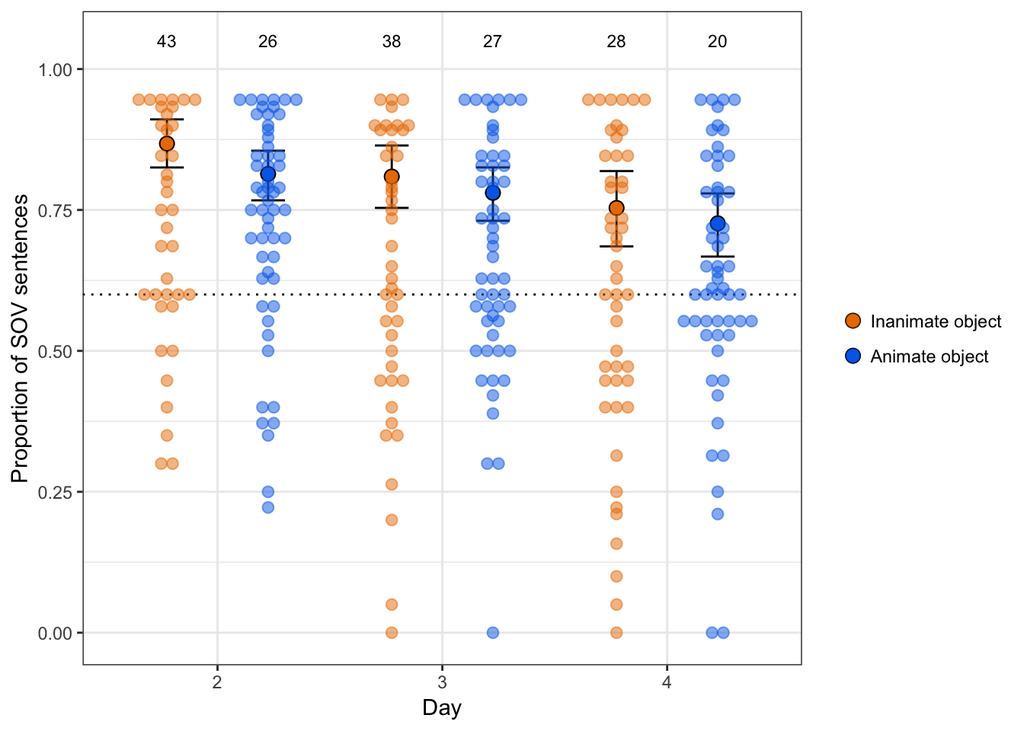

```r
exp2.sov.summary.by.animacy.collapsed <- aggregate(isSOV~Animacy+Day+workerId,data=subset(exp2Data,Block=="SentenceTest1" & grammatical),FUN=mean)

#for the collapsed dotplot, there are too many participants at ceiling to show the dots - instead I am going
#to withhold those dots and add a numerical annotation
exp2.sov.summary.by.animacy.collapsed$IsPerfect <- ifelse(exp2.sov.summary.by.animacy.collapsed$isSOV==1,1,0)
exp2.sov.summary.by.animacy.collapsed$Day <- droplevels(exp2.sov.summary.by.animacy.collapsed$Day)
exp2.allsov.ns <- data.frame(summarize(group_by(subset(exp2.sov.summary.by.animacy.collapsed,IsPerfect==1 & Day!=1),Day,Animacy,.drop = FALSE),n()))
exp2.allsov.ns <- plyr::rename(exp2.allsov.ns,c("n.."="count"))



ggplot(data=exp2.sov.summary.by.animacy.collapsed, aes(x=Day, y=isSOV, fill=Animacy,colour=Animacy)) +
  #points and CIs for word order by animacy
  stat_summary(geom='errorbar', fun.data='mean_cl_boot',fun.ymin="min", fun.ymax="max",width=0.3,position=position_dodge(0.9),color='black') +
  stat_summary(geom='point', fun.y='mean', position=position_dodge(0.9), size=3) +
  stat_summary(geom='point', fun.y='mean', position=position_dodge(0.9), size=3, shape=1, colour='black') +


  #horizontal line showing input
  geom_hline(yintercept=0.6,linetype=3) +

  #by-participant data
  geom_dotplot(data=subset(exp2.sov.summary.by.animacy.collapsed,IsPerfect!=1),aes(x=Day, y=isSOV, shape=Animacy),binaxis = "y", stackdir = "center",alpha=0.5,dotsize=2,position=position_dodge(0.9),binpositions='all',binwidth=1/100) +
  geom_text(data=exp2.allsov.ns,aes(x=Day,y=1.05,label=count),position=position_dodge(0.9),size=3,colour='black') +

  #then various axis/legend stuff
  xlab("Day") +
  theme_bw() +
  ylab("Proportion of SOV sentences") +
  theme(legend.title=element_blank()) +
  scale_colour_manual(values=my.colours[2:3],breaks=c("FALSE", "TRUE"),labels=c("Inanimate object", "Animate object")) +
  scale_fill_manual(values=my.colours[2:3],breaks=c("FALSE", "TRUE"),labels=c("Inanimate object", "Animate object")) +
  ggsave("../Figures/exp2-wordorder-collapsed.pdf",width=9, height=4.5)
```

```r
contrasts(exp2Data$Animacy) <- c(-0.5,0.5)
contrasts(exp2Data$EventType) <- c(-0.5,0.5)


exp2.sovorder.model.1 <- glmer(isSOV ~ Animacy * EventType * Day + (1 + Animacy * Day | workerId),data=subset(exp2Data,Block=="SentenceTest1" & grammatical),family=binomial,control=glmerControl(optimizer="bobyqa",optCtrl=list(maxfun=50000)))
```

```r
exp2.sovorder.model.2 <- glmer(isSOV ~ Animacy * Day + (1 + Animacy * Day | workerId),data=subset(exp2Data,Block=="SentenceTest1" & grammatical),family=binomial,control=glmerControl(optimizer="bobyqa",optCtrl=list(maxfun=50000)))
```

```
## boundary (singular) fit: see ?isSingular
```

That produces singular fit, simplifying. Still singular.

```r
exp2.sovorder.model.3 <- glmer(isSOV ~ Animacy * Day + (1 | workerId) + (0 + Animacy * Day | workerId),data=subset(exp2Data,Block=="SentenceTest1" & grammatical),family=binomial,control=glmerControl(optimizer="bobyqa",optCtrl=list(maxfun=50000)))
```

```
## boundary (singular) fit: see ?isSingular
```

Trying pulling out the interaction. Works.

```r
exp2.sovorder.model.4 <- glmer(isSOV ~ Animacy * Day + (1 | workerId) + (0 + Animacy + Day | workerId),data=subset(exp2Data,Block=="SentenceTest1" & grammatical),family=binomial,control=glmerControl(optimizer="bobyqa",optCtrl=list(maxfun=50000)))
```

```r
summary(exp2.sovorder.model.4)
```

```
## Generalized linear mixed model fit by maximum likelihood (Laplace Approximation) ['glmerMod']
##  Family: binomial  ( logit )
## Formula: isSOV ~ Animacy * Day + (1 | workerId) + (0 + Animacy + Day |      workerId)
##    Data: subset(exp2Data, Block == "SentenceTest1" & grammatical)
## Control: glmerControl(optimizer = "bobyqa", optCtrl = list(maxfun = 50000))
##
##      AIC      BIC   logLik deviance df.resid
##   6561.1   6681.0  -3263.6   6527.1     8521
##
## Scaled residuals:
##      Min       1Q   Median       3Q      Max
## -12.8416   0.0418   0.1626   0.4580   5.4702
##
## Random effects:
##  Groups     Name         Variance Std.Dev. Corr
##  workerId   (Intercept)  0.5473   0.7398
##  workerId.1 AnimacyFALSE 6.1672   2.4834
##             AnimacyTRUE  2.3495   1.5328    0.97
##             Day3         1.2425   1.1147    0.01 -0.04
##             Day4         3.1432   1.7729   -0.28 -0.40  0.78
## Number of obs: 8538, groups:  workerId, 84
##
## Fixed effects:
##               Estimate Std. Error z value Pr(>|z|)
## (Intercept)     2.8648     0.2670  10.731  < 2e-16 ***
## Animacy1       -1.2769     0.2081  -6.135 8.51e-10 ***
## Day3           -0.2466     0.2039  -1.209  0.22662
## Day4           -0.8202     0.2546  -3.221  0.00128 **
## Animacy1:Day3   0.3461     0.1719   2.013  0.04412 *
## Animacy1:Day4   0.4727     0.1730   2.733  0.00628 **
## ---
## Signif. codes:  0 '***' 0.001 '**' 0.01 '*' 0.05 '.' 0.1 ' ' 1
##
## Correlation of Fixed Effects:
##             (Intr) Anmcy1 Day3   Day4   An1:D3
## Animacy1    -0.572
## Day3        -0.262  0.070
## Day4        -0.433  0.119  0.656
## Animcy1:Dy3  0.078 -0.484 -0.157 -0.083
## Animcy1:Dy4  0.092 -0.527 -0.107 -0.128  0.593
```

The log-odds of producing SOV order are significantly higher than the frequency of SOV in the input:

```r
my.logodds.p(0.6,exp2.sovorder.model.4,"(Intercept)")
```

```
## [1] 3.203159e-20
```

## Word order and case correlation

Recall that in the input SOV is *less* likely to be case marked than OSV in Exp 2. It looks like they are pretty much on the money with this in Experiment 2, or exagerating this feature of their input (i.e. marking OSV *more* than 50%, and SOV less than 33%).

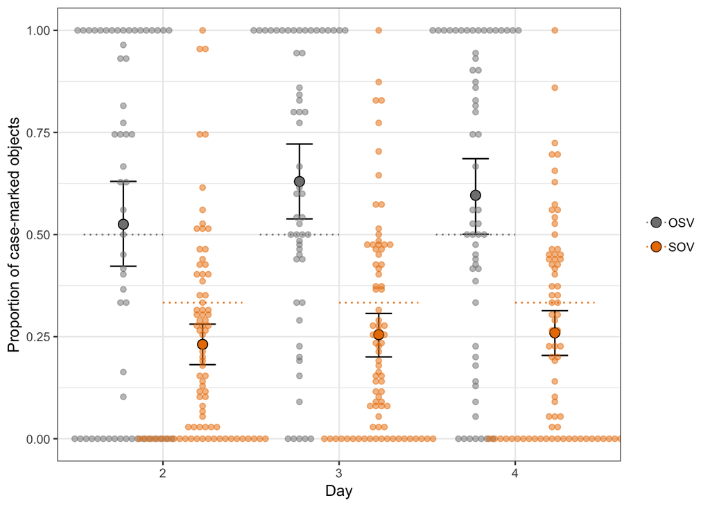

```r
exp2.case.summary.by.order.collapsed <- aggregate(casemarked~Day+WordOrder+workerId,data=subset(exp2Data,Block=="SentenceTest1" & grammatical),FUN=mean)

exp2.inputs <- data.frame(Day=rep(c(1,2,3),2),
                          WordOrder=rep(c('OSV','SOV'),each=3),
                          casemarked=rep(c(1/2,1/3),each=3))

ggplot(data=exp2.case.summary.by.order.collapsed, aes(x=Day, y=casemarked, fill=WordOrder, colour=WordOrder)) +
  #points and CIs for marking by word order
  stat_summary(geom='errorbar', fun.data='mean_cl_boot',fun.ymin="min", fun.ymax="max",width=0.3,position=position_dodge(0.9),color='black') +
  stat_summary(geom='point', fun.y='mean', position=position_dodge(0.9), size=3) +
  stat_summary(geom='point', fun.y='mean', position=position_dodge(0.9), size=3, shape=1, colour='black') +

  #horizontal lines showing input
  geom_errorbar(data=exp2.inputs, aes(x=Day,ymax=casemarked, ymin=casemarked),position=position_dodge(0.9),linetype=3) +

  #by-participant data
  geom_dotplot(aes(x=Day, y=casemarked, shape=WordOrder),binaxis = "y", stackdir = "center",alpha=0.5,dotsize=1.4,position=position_dodge(0.9),binpositions='all',binwidth=1/100) +

  #then various axis/legend stuff
  xlab("Day") +
  theme_bw() +
  ylab("Proportion of case-marked objects") +
  theme(legend.title=element_blank()) +
  scale_fill_manual(values=my.colours) +
  scale_colour_manual(values=my.colours) +
  ggsave("../Figures/exp2-case-by-order-collapsed.pdf",width=9, height=4.5)
```

```r
contrasts(exp2Data$WordOrder) <- c(-0.5,0.5)
exp2.caseorder.model.2 <- glmer(casemarked ~ WordOrder * Day + (1 + WordOrder * Day | workerId),data=subset(exp2Data,Block=="SentenceTest1" & grammatical),family=binomial,control=glmerControl(optimizer="bobyqa",optCtrl=list(maxfun=50000)))
```

```r
summary(exp2.caseorder.model.2)
```

```
## Generalized linear mixed model fit by maximum likelihood (Laplace Approximation) ['glmerMod']
##  Family: binomial  ( logit )
## Formula: casemarked ~ WordOrder * Day + (1 + WordOrder * Day | workerId)
##    Data: subset(exp2Data, Block == "SentenceTest1" & grammatical)
## Control: glmerControl(optimizer = "bobyqa", optCtrl = list(maxfun = 50000))
##
##      AIC      BIC   logLik deviance df.resid
##   7424.3   7614.7  -3685.1   7370.3     8511
##
## Scaled residuals:
##     Min      1Q  Median      3Q     Max
## -5.1439 -0.5722 -0.1527  0.3431  6.7130
##
## Random effects:
##  Groups   Name            Variance Std.Dev. Corr
##  workerId (Intercept)     6.966    2.639
##           WordOrder1      5.909    2.431    -0.54
##           Day3            2.042    1.429    -0.65  0.40
##           Day4            2.538    1.593    -0.56  0.24  0.65
##           WordOrder1:Day3 5.447    2.334     0.48 -0.81 -0.26 -0.18
##           WordOrder1:Day4 5.536    2.353     0.40 -0.73 -0.15 -0.18  0.88
## Number of obs: 8538, groups:  workerId, 84
##
## Fixed effects:
##                 Estimate Std. Error z value Pr(>|z|)
## (Intercept)      -1.1714     0.3319  -3.529 0.000417 ***
## WordOrder1       -1.8351     0.4186  -4.384 1.17e-05 ***
## Day3              0.4177     0.2379   1.756 0.079173 .
## Day4              0.2357     0.2632   0.895 0.370600
## WordOrder1:Day3  -0.3987     0.4367  -0.913 0.361222
## WordOrder1:Day4  -0.3736     0.4674  -0.799 0.424080
## ---
## Signif. codes:  0 '***' 0.001 '**' 0.01 '*' 0.05 '.' 0.1 ' ' 1
##
## Correlation of Fixed Effects:
##             (Intr) WrdOr1 Day3   Day4   WO1:D3
## WordOrder1  -0.579
## Day3        -0.675  0.494
## Day4        -0.607  0.409  0.673
## WrdOrdr1:D3  0.475 -0.813 -0.477 -0.354
## WrdOrdr1:D4  0.424 -0.750 -0.349 -0.429  0.751
```

## Case marking and animacy during sentence recall

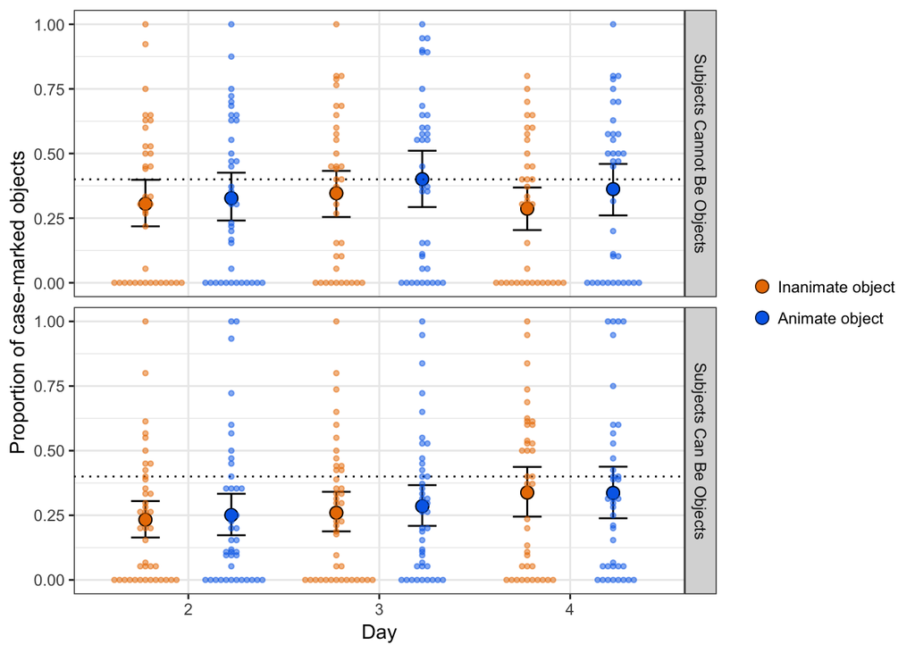

```r
exp2.casemarking.summary.by.animacy <- aggregate(casemarked~Animacy+Day+EventType+workerId,data=subset(exp2Data,Block=="SentenceTest1" & grammatical),FUN=mean)


ggplot(data=exp2.casemarking.summary.by.animacy, aes(x=Day, y=casemarked,
                                                     colour=Animacy,fill=Animacy)) +
  facet_grid(EventType~.) +
  #bars and CIs for casemarking by animacy
  stat_summary(geom='errorbar', fun.data='mean_cl_boot',fun.ymin="min", fun.ymax="max",width=0.3,position=position_dodge(0.9),colour='black') +
  stat_summary(geom='point',fun.y='mean', position=position_dodge(0.9),size=3) +
  stat_summary(geom='point',fun.y='mean', position=position_dodge(0.9),size=3,shape=1,colour='black') +

  #horizontal line showing input
  geom_hline(yintercept=0.4,linetype=3) +
  #by-participant data
  geom_dotplot(aes(x=Day, y=casemarked, shape=Animacy),binaxis = "y", stackdir = "centerwhole",stackratio=1,alpha=0.5,dotsize=2,position=position_dodge(0.9),binpositions='all',binwidth=1/100) +
  #geom_point(aes(x=Day, y=casemarked, shape=Animacy),alpha=0.2,dotsize=1,position=position_jitterdodge(jitter.width= 0.2, jitter.height = 0,dodge.width = 0.9),fill='black') +
  #force all points to be circles, and exclude from legend
  scale_shape_manual(values=c(21,21),guide=FALSE)+
  #then various axis/legend stuff
  xlab("Day") +
  theme_bw() +
  ylab("Proportion of case-marked objects") +
  theme(legend.title=element_blank()) +
  scale_fill_manual(values=my.colours[2:3],breaks=c("FALSE", "TRUE"),labels=c("Inanimate object", "Animate object")) +
  scale_colour_manual(values=my.colours[2:3],breaks=c("FALSE", "TRUE"),labels=c("Inanimate object", "Animate object")) +
  ggsave("../Figures/exp2-casemarking.pdf",width=9, height=9)
```

```r
#Using a coding scheme such that the estimate for animacy and condition will be the effect of a one-unit difference - i.e. unlike contr.sum you don't have to double this.
exp2Data$Animacy <- factor(exp2Data$Animacy)
contrasts(exp2Data$Animacy) <- c(-0.5,0.5)
contrasts(exp2Data$EventType) <- c(-0.5,0.5)
exp2.case.marking.model.1 <- glmer(casemarked ~ Animacy * Day * EventType + (1 + Animacy * Day | workerId),data=subset(exp2Data,Block=="SentenceTest1" & grammatical),family=binomial,control=glmerControl(optimizer="bobyqa",optCtrl=list(maxfun=50000)))
```

```
## boundary (singular) fit: see ?isSingular
```

The full model produces a singular fit, simplifying by removing correlation.

```r
exp2.case.marking.model.2 <- glmer(casemarked ~ Animacy * Day * EventType + (1 | workerId) + (0 + Animacy * Day | workerId),data=subset(exp2Data,Block=="SentenceTest1" & grammatical),family=binomial,control=glmerControl(optimizer="bobyqa",optCtrl=list(maxfun=50000)))
```

```
## boundary (singular) fit: see ?isSingular
```

Still singular, removing interaction. This converges.

```r
exp2.case.marking.model.3 <- glmer(casemarked ~ Animacy * Day * EventType + (1 | workerId) + (0 + Animacy + Day | workerId),data=subset(exp2Data,Block=="SentenceTest1" & grammatical),family=binomial,control=glmerControl(optimizer="bobyqa",optCtrl=list(maxfun=50000)))
```

```r
summary(exp2.case.marking.model.3)
```

```
## Generalized linear mixed model fit by maximum likelihood (Laplace Approximation) ['glmerMod']
##  Family: binomial  ( logit )
## Formula: casemarked ~ Animacy * Day * EventType + (1 | workerId) + (0 +      Animacy + Day | workerId)
##    Data: subset(exp2Data, Block == "SentenceTest1" & grammatical)
## Control: glmerControl(optimizer = "bobyqa", optCtrl = list(maxfun = 50000))
##
##      AIC      BIC   logLik deviance df.resid
##   7814.7   7976.9  -3884.4   7768.7     8515
##
## Scaled residuals:
##     Min      1Q  Median      3Q     Max
## -6.3206 -0.5779 -0.1403  0.4922  7.4586
##
## Random effects:
##  Groups     Name         Variance Std.Dev. Corr
##  workerId   (Intercept)  2.944    1.716
##  workerId.1 AnimacyFALSE 3.625    1.904
##             AnimacyTRUE  3.963    1.991     0.70
##             Day3         2.353    1.534    -0.69 -0.63
##             Day4         3.161    1.778    -0.59 -0.53  0.64
## Number of obs: 8538, groups:  workerId, 84
##
## Fixed effects:
##                          Estimate Std. Error z value Pr(>|z|)
## (Intercept)              -1.85486    0.29267  -6.338 2.33e-10 ***
## Animacy1                  0.38484    0.21537   1.787   0.0740 .
## Day3                      0.41628    0.21399   1.945   0.0517 .
## Day4                      0.29941    0.24564   1.219   0.2229
## EventType1               -0.25408    0.57280  -0.444   0.6573
## Animacy1:Day3            -0.09988    0.15287  -0.653   0.5135
## Animacy1:Day4            -0.14464    0.15704  -0.921   0.3570
## Animacy1:EventType1       0.30458    0.41672   0.731   0.4648
## Day3:EventType1          -0.10626    0.40339  -0.263   0.7922
## Day4:EventType1           0.84415    0.46896   1.800   0.0719 .
## Animacy1:Day3:EventType1 -0.32475    0.30308  -1.072   0.2839
## Animacy1:Day4:EventType1 -0.51764    0.31152  -1.662   0.0966 .
## ---
## Signif. codes:  0 '***' 0.001 '**' 0.01 '*' 0.05 '.' 0.1 ' ' 1
##
## Correlation of Fixed Effects:
##             (Intr) Anmcy1 Day3   Day4   EvntT1 An1:D3 An1:D4 A1:ET1 D3:ET1 D4:ET1 A1:D3:
## Animacy1     0.006
## Day3        -0.553  0.049
## Day4        -0.483  0.051  0.625
## EventType1  -0.080 -0.005  0.052  0.042
## Animcy1:Dy3  0.024 -0.407 -0.032 -0.023  0.002
## Animcy1:Dy4  0.025 -0.397 -0.026 -0.028  0.003  0.563
## Anmcy1:EvT1 -0.012 -0.058  0.009  0.010  0.026 -0.022 -0.029
## Dy3:EvntTy1  0.053  0.000 -0.099 -0.060 -0.539 -0.006 -0.004  0.033
## Dy4:EvntTy1  0.043  0.002 -0.058 -0.093 -0.466 -0.006 -0.006  0.038  0.625
## Anm1:D3:ET1  0.010 -0.018 -0.016 -0.012  0.007  0.010  0.022 -0.414 -0.010 -0.008
## Anm1:D4:ET1  0.011 -0.030 -0.012 -0.007  0.008  0.019  0.032 -0.403 -0.008 -0.012  0.558
```

The odds of producing a case marker are approximately -1.85 to 1, which is significantly lower than the frequency of case marking in the input (where case marking occurs on 40% of objects, i.e. log odds of:

```r
prob2logit(0.4)
```

```
## [1] -0.4054651
```

, significantly different from the estimated log odds on Day 2,

```r
my.logodds.p(0.4,exp2.case.marking.model.1,"(Intercept)")
```

```
## [1] 4.498683e-07
```

If I instead run this model on the full data set but setting day 4 as the intercept, there’s absolutely no significant effect of animacy, indicating that while the relationship between animacy and case marking changes over the course of the experiment, participants’ use of case markers on day 4 does not show a significant DOM-like effect.

```r
#code day 4 as 0 to see if case marking is significantly affected by animacy on day 4
exp2Data$DayR <- relevel(exp2Data$Day,ref='4')

exp2.case.marking.model.3r <- glmer(casemarked ~ Animacy * DayR * EventType + (1 | workerId) + (0 + Animacy + DayR | workerId),data=subset(exp2Data,Block=="SentenceTest1" & grammatical),family=binomial,control=glmerControl(optimizer="bobyqa",optCtrl=list(maxfun=50000)))
```

```r
summary(exp2.case.marking.model.3r)
```

```
## Generalized linear mixed model fit by maximum likelihood (Laplace Approximation) ['glmerMod']
##  Family: binomial  ( logit )
## Formula: casemarked ~ Animacy * DayR * EventType + (1 | workerId) + (0 +      Animacy + DayR | workerId)
##    Data: subset(exp2Data, Block == "SentenceTest1" & grammatical)
## Control: glmerControl(optimizer = "bobyqa", optCtrl = list(maxfun = 50000))
##
##      AIC      BIC   logLik deviance df.resid
##   7814.7   7976.9  -3884.4   7768.7     8515
##
## Scaled residuals:
##     Min      1Q  Median      3Q     Max
## -6.3207 -0.5779 -0.1403  0.4922  7.4592
##
## Random effects:
##  Groups     Name         Variance Std.Dev. Corr
##  workerId   (Intercept)  3.281    1.811
##  workerId.1 AnimacyFALSE 2.451    1.566
##             AnimacyTRUE  3.024    1.739     0.59
##             DayR2        3.161    1.778    -0.42 -0.41
##             DayR3        2.032    1.426    -0.64 -0.59  0.56
## Number of obs: 8538, groups:  workerId, 84
##
## Fixed effects:
##                           Estimate Std. Error z value Pr(>|z|)
## (Intercept)               -1.55535    0.27637  -5.628 1.83e-08 ***
## Animacy1                   0.24021    0.21018   1.143   0.2531
## DayR2                     -0.29970    0.24547  -1.221   0.2221
## DayR3                      0.11676    0.20104   0.581   0.5614
## EventType1                 0.58995    0.54561   1.081   0.2796
## Animacy1:DayR2             0.14465    0.15703   0.921   0.3570
## Animacy1:DayR3             0.04477    0.14493   0.309   0.7574
## Animacy1:EventType1       -0.21306    0.40684  -0.524   0.6005
## DayR2:EventType1          -0.84393    0.46867  -1.801   0.0718 .
## DayR3:EventType1          -0.95030    0.38158  -2.490   0.0128 *
## Animacy1:DayR2:EventType1  0.51766    0.31146   1.662   0.0965 .
## Animacy1:DayR3:EventType1  0.19289    0.28872   0.668   0.5041
## ---
## Signif. codes:  0 '***' 0.001 '**' 0.01 '*' 0.05 '.' 0.1 ' ' 1
##
## Correlation of Fixed Effects:
##             (Intr) Anmcy1 DayR2  DayR3  EvntT1 An1:DR2 An1:DR3 A1:ET1 DR2:ET DR3:ET A1:DR2:
## Animacy1     0.054
## DayR2       -0.376 -0.031
## DayR3       -0.492 -0.005  0.556
## EventType1  -0.081 -0.004  0.035  0.049
## Anmcy1:DyR2 -0.001 -0.340 -0.028 -0.007  0.002
## Anmcy1:DyR3  0.004 -0.365 -0.006 -0.014 -0.001  0.490
## Anmcy1:EvT1  0.001 -0.088 -0.005 -0.006  0.059  0.005  -0.002
## DyR2:EvntT1  0.037  0.002 -0.093 -0.052 -0.368 -0.006  -0.001  -0.030
## DyR3:EvntT1  0.049  0.000 -0.051 -0.098 -0.483 -0.004  -0.003  -0.007  0.566
## An1:DR2:ET1 -0.005  0.007 -0.007  0.005  0.002  0.032   0.014  -0.350 -0.013 -0.006
## An1:DR3:ET1 -0.005  0.005  0.006  0.003  0.003  0.012   0.002  -0.375 -0.004 -0.006  0.492
```

Statistic controlling for word order - but note that animacy and word order will be collinear. Building this to only include the interactions that are meaningful, i.e. order * animacy * day, and condition * animacy * day, but not anything involving both condition and order.

This model produces a singular fit.

```r
contrasts(exp2Data$WordOrder) <- c(-0.5,0.5)
exp2.case.marking.model.4 <- glmer(casemarked ~ Animacy * Day * (WordOrder + EventType)
                                     + (1 + Animacy * Day * WordOrder  | workerId),data=subset(exp2Data,Block=="SentenceTest1" & grammatical),family=binomial,control=glmerControl(optimizer="bobyqa",optCtrl=list(maxfun=50000)))
```

```
## boundary (singular) fit: see ?isSingular
```

Simplifying, removing 3-way interaction in random effects.

```r
contrasts(exp2Data$WordOrder) <- c(-0.5,0.5)
exp2.case.marking.model.5 <- glmer(casemarked ~ Animacy * Day * (WordOrder + EventType)
                                     + (1 | workerId) + (0 + Animacy * Day * WordOrder
                                      - Animacy:Day:WordOrder  | workerId),data=subset(exp2Data,Block=="SentenceTest1" & grammatical),family=binomial,control=glmerControl(optimizer="bobyqa",optCtrl=list(maxfun=50000)))
```

```
## boundary (singular) fit: see ?isSingular
```

Still singular, simplifying by pulling out 2-way interactions in random effects. Two ways to do this, trying both. Model 6 and 7 both converge, show similar things.

```r
contrasts(exp2Data$WordOrder) <- c(-0.5,0.5)
exp2.case.marking.model.6 <- glmer(casemarked ~ Animacy * Day * (WordOrder + EventType)
                                     + (1 | workerId) + (0 + Animacy * Day * WordOrder
                                      - Animacy:Day:WordOrder
                                      - Animacy:Day | workerId),data=subset(exp2Data,Block=="SentenceTest1" & grammatical),family=binomial,control=glmerControl(optimizer="bobyqa",optCtrl=list(maxfun=50000)))

exp2.case.marking.model.7 <- glmer(casemarked ~ Animacy * Day * (WordOrder + EventType)
                                     + (1 | workerId) + (0 + Animacy * Day * WordOrder
                                      - Animacy:Day:WordOrder
                                      - Animacy:WordOrder | workerId),data=subset(exp2Data,Block=="SentenceTest1" & grammatical),family=binomial,control=glmerControl(optimizer="bobyqa",optCtrl=list(maxfun=50000)))
```

This model shows a clear effect of word order on case marking (as is present in the participants’ input) but no effect of animacy - note several quite high VIFs.

```r
summary(exp2.case.marking.model.6)
```

```
## Generalized linear mixed model fit by maximum likelihood (Laplace Approximation) ['glmerMod']
##  Family: binomial  ( logit )
## Formula: casemarked ~ Animacy * Day * (WordOrder + EventType) + (1 | workerId) +      (0 + Animacy * Day * WordOrder - Animacy:Day:WordOrder -          Animacy:Day | workerId)
##    Data: subset(exp2Data, Block == "SentenceTest1" & grammatical)
## Control: glmerControl(optimizer = "bobyqa", optCtrl = list(maxfun = 50000))
##
##      AIC      BIC   logLik deviance df.resid
##   7129.7   7517.6  -3509.9   7019.7     8483
##
## Scaled residuals:
##     Min      1Q  Median      3Q     Max
## -4.6190 -0.4535 -0.1206  0.3007  7.5036
##
## Random effects:
##  Groups     Name                Variance Std.Dev. Corr
##  workerId   (Intercept)         1.111    1.054
##  workerId.1 AnimacyFALSE        8.683    2.947
##             AnimacyTRUE         9.401    3.066     0.89
##             Day3                3.236    1.799    -0.81 -0.77
##             Day4                3.728    1.931    -0.71 -0.65  0.76
##             WordOrder1          7.332    2.708    -0.63 -0.59  0.43  0.35
##             Animacy1:WordOrder1 1.064    1.032     0.52  0.67 -0.47 -0.68 -0.50
##             Day3:WordOrder1     6.848    2.617     0.56  0.56 -0.32 -0.27 -0.85  0.32
##             Day4:WordOrder1     7.227    2.688     0.46  0.45 -0.17 -0.19 -0.77  0.43  0.92
## Number of obs: 8538, groups:  workerId, 84
##
## Fixed effects:
##                          Estimate Std. Error z value Pr(>|z|)
## (Intercept)              -1.25446    0.38473  -3.261  0.00111 **
## Animacy1                 -0.03908    0.25195  -0.155  0.87674
## Day3                      0.45789    0.27695   1.653  0.09827 .
## Day4                      0.21195    0.29953   0.708  0.47919
## WordOrder1               -2.00417    0.46410  -4.318 1.57e-05 ***
## EventType1               -0.68259    0.61486  -1.110  0.26693
## Animacy1:Day3             0.20179    0.21893   0.922  0.35669
## Animacy1:Day4             0.04001    0.22491   0.178  0.85881
## Animacy1:WordOrder1       0.45558    0.41164   1.107  0.26840
## Animacy1:EventType1       0.05268    0.44627   0.118  0.90602
## Day3:WordOrder1          -0.32194    0.47911  -0.672  0.50161
## Day4:WordOrder1          -0.25572    0.51109  -0.500  0.61683
## Day3:EventType1           0.10880    0.44420   0.245  0.80651
## Day4:EventType1           0.97443    0.49549   1.967  0.04923 *
## Animacy1:Day3:WordOrder1 -0.69224    0.43927  -1.576  0.11506
## Animacy1:Day4:WordOrder1 -0.17217    0.45608  -0.377  0.70581
## Animacy1:Day3:EventType1 -0.23948    0.33798  -0.709  0.47860
## Animacy1:Day4:EventType1 -0.36361    0.35706  -1.018  0.30852
## ---
## Signif. codes:  0 '***' 0.001 '**' 0.01 '*' 0.05 '.' 0.1 ' ' 1
```

```
##
## Correlation matrix not shown by default, as p = 18 > 12.
## Use print(x, correlation=TRUE)  or
##     vcov(x)        if you need it
```

```r
car::vif(exp2.case.marking.model.6)
```

```
##                           GVIF Df GVIF^(1/(2*Df))
## Animacy               1.773841  1        1.331856
## Day                   1.722544  2        1.145625
## WordOrder             4.303041  1        2.074377
## EventType             1.791048  1        1.338300
## Animacy:Day           3.033391  2        1.319721
## Animacy:WordOrder     2.933284  1        1.712683
## Animacy:EventType     1.418074  1        1.190829
## Day:WordOrder         4.624706  2        1.466463
## Day:EventType         1.776418  2        1.154480
## Animacy:Day:WordOrder 4.253122  2        1.436075
## Animacy:Day:EventType 1.438268  2        1.095116
```

This model shows a clear effect of word order on case marking (as is present in the participants’ input) but no effect of animacy - note several quite high VIFs. The marginal animacy x day=3 x order interaction indicates *less* marking of animates on day 3 in SOV order, which would be an anti-DOM effect and is gone by day 4 anyway.

```r
summary(exp2.case.marking.model.7)
```

```
## Generalized linear mixed model fit by maximum likelihood (Laplace Approximation) ['glmerMod']
##  Family: binomial  ( logit )
## Formula: casemarked ~ Animacy * Day * (WordOrder + EventType) + (1 | workerId) +      (0 + Animacy * Day * WordOrder - Animacy:Day:WordOrder -          Animacy:WordOrder | workerId)
##    Data: subset(exp2Data, Block == "SentenceTest1" & grammatical)
## Control: glmerControl(optimizer = "bobyqa", optCtrl = list(maxfun = 50000))
##
##      AIC      BIC   logLik deviance df.resid
##   7130.0   7581.3  -3501.0   7002.0     8474
##
## Scaled residuals:
##     Min      1Q  Median      3Q     Max
## -5.0419 -0.4755 -0.1298  0.2925  7.4752
##
## Random effects:
##  Groups     Name            Variance  Std.Dev. Corr
##  workerId   (Intercept)     8.029e-07 0.000896
##  workerId.1 AnimacyFALSE    8.047e+00 2.836750
##             AnimacyTRUE     8.813e+00 2.968656  0.90
##             Day3            2.564e+00 1.601159 -0.70 -0.58
##             Day4            2.992e+00 1.729756 -0.54 -0.53  0.67
##             WordOrder1      6.024e+00 2.454298 -0.60 -0.45  0.37  0.27
##             Animacy1:Day3   1.121e+00 1.058847 -0.03  0.02 -0.12  0.40 -0.28
##             Animacy1:Day4   1.728e+00 1.314612  0.35  0.31 -0.48  0.08 -0.62  0.86
##             Day3:WordOrder1 5.184e+00 2.276834  0.49  0.38 -0.19 -0.15 -0.80  0.24  0.51
##             Day4:WordOrder1 6.090e+00 2.467737  0.38  0.29 -0.06 -0.11 -0.71 -0.02  0.29  0.92
## Number of obs: 8538, groups:  workerId, 84
##
## Fixed effects:
##                          Estimate Std. Error z value Pr(>|z|)
## (Intercept)              -1.21953    0.35236  -3.461 0.000538 ***
## Animacy1                 -0.13528    0.25337  -0.534 0.593384
## Day3                      0.38460    0.25680   1.498 0.134216
## Day4                      0.24510    0.28244   0.868 0.385505
## WordOrder1               -1.94602    0.42624  -4.566 4.98e-06 ***
## EventType1               -0.49198    0.57926  -0.849 0.395694
## Animacy1:Day3             0.41857    0.29228   1.432 0.152119
## Animacy1:Day4             0.17290    0.31305   0.552 0.580731
## Animacy1:WordOrder1       0.48549    0.37226   1.304 0.192175
## Animacy1:EventType1       0.07695    0.38902   0.198 0.843203
## Day3:WordOrder1          -0.36274    0.44100  -0.823 0.410779
## Day4:WordOrder1          -0.43805    0.49644  -0.882 0.377565
## Day3:EventType1          -0.00684    0.41905  -0.016 0.986978
## Day4:EventType1           0.78232    0.47969   1.631 0.102911
## Animacy1:Day3:WordOrder1 -0.84549    0.46667  -1.812 0.070026 .
## Animacy1:Day4:WordOrder1 -0.43850    0.47629  -0.921 0.357223
## Animacy1:Day3:EventType1 -0.12295    0.42444  -0.290 0.772057
## Animacy1:Day4:EventType1 -0.27575    0.45788  -0.602 0.547025
## ---
## Signif. codes:  0 '***' 0.001 '**' 0.01 '*' 0.05 '.' 0.1 ' ' 1
```

```
##
## Correlation matrix not shown by default, as p = 18 > 12.
## Use print(x, correlation=TRUE)  or
##     vcov(x)        if you need it
```

```r
car::vif(exp2.case.marking.model.7)
```

```
##                           GVIF Df GVIF^(1/(2*Df))
## Animacy               1.742922  1        1.320198
## Day                   1.685039  2        1.139338
## WordOrder             3.399382  1        1.843741
## EventType             1.612588  1        1.269877
## Animacy:Day           2.125914  2        1.207498
## Animacy:WordOrder     3.968895  1        1.992209
## Animacy:EventType     1.254644  1        1.120109
## Day:WordOrder         3.693098  2        1.386270
## Day:EventType         1.748818  2        1.149969
## Animacy:Day:WordOrder 4.128511  2        1.425438
## Animacy:Day:EventType 1.358780  2        1.079661
```

## Communicative accuracy in interaction.

```r
#since there is some data munging here, will set this up as a seperate data frame
exp2InteractionSuccessData <- droplevels(subset(exp2Data,((Block=="Interaction" & grammatical) | (Block=="InteractionMatch")) & Day==4))

exp2.interaction.success.summary <- aggregate(score~Block+Animacy+EventType+casemarked+workerId,data=exp2InteractionSuccessData,FUN=mean)

exp2.interaction.success.summary$casemarked <- revalue(as.factor(exp2.interaction.success.summary$casemarked),
                                    c("FALSE"="Object not casemarked",
                                      "TRUE"="Object casemarked"))
exp2.interaction.success.summary$Block <- plyr::revalue(exp2.interaction.success.summary$Block,
                                                        c("Interaction"="Participant Directs,\nSmeeble Matches",
                                                          "InteractionMatch"="Smeeble Directs,\nParticipant Matches"))

#for the dotplot, there are too many participants at ceiling to show the dots - instead I am going
#to withhold those dots and add a numerical annotation
exp2.interaction.success.summary$IsPerfect <- ifelse(exp2.interaction.success.summary$score==1,1,0)
exp2.interaction.score.perfect.ns <- data.frame(summarize(group_by(subset(exp2.interaction.success.summary,IsPerfect==1),Block,Animacy,casemarked,EventType,.drop = FALSE),n()))
exp2.interaction.score.perfect.ns <- plyr::rename(exp2.interaction.score.perfect.ns,c("n.."="count"))
```

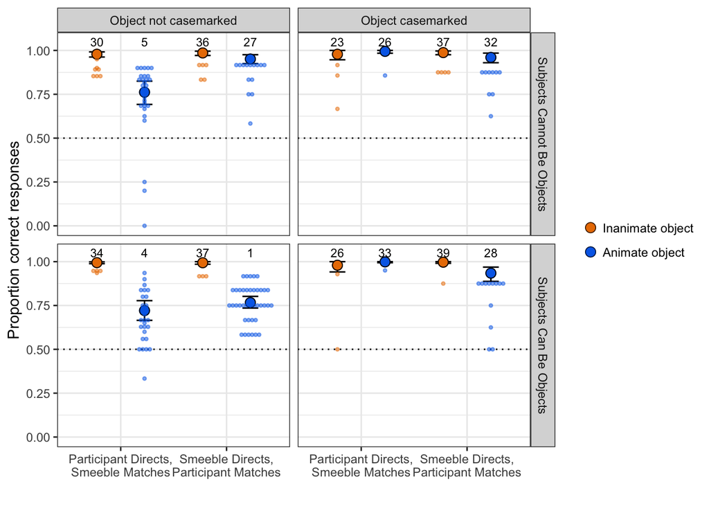

```r
ggplot(data=exp2.interaction.success.summary, aes(x=Block, y=score,
                                                  colour=Animacy,fill=Animacy)) +
  facet_grid(EventType~casemarked) +
  #points and CIs for casemarking by animacy
  stat_summary(geom='errorbar', fun.data='mean_cl_boot',fun.ymin="min",
               fun.ymax="max",width=0.3,position=position_dodge(0.9),color='black') +
  stat_summary(geom='point', fun.y='mean', position=position_dodge(0.9),size=3) +
  stat_summary(geom='point', fun.y='mean', position=position_dodge(0.9),size=3,
               shape=1,colour='black') +


  #horizontal line showing chance
  geom_hline(yintercept=0.5,linetype=3) +
  #by-participant data
  geom_dotplot(data=subset(exp2.interaction.success.summary,IsPerfect==0),aes(x=Block, y=score, shape=Animacy),binaxis = "y", stackdir = "center",alpha=0.5,dotsize=2,position=position_dodge(0.9),binpositions='all',binwidth=1/100) +
  geom_text(data=exp2.interaction.score.perfect.ns,aes(x=Block,y=1.05,label=count),position=position_dodge(0.9),size=3,colour='black') +

  #then various axis/legend stuff
  xlab("") +
  theme_bw() +
  scale_y_continuous(name="Proportion correct responses",breaks=seq(0,1,0.25)) +
  theme(legend.title=element_blank()) +
  scale_colour_manual(values=my.colours[c(2,3)],breaks=c("FALSE", "TRUE"),labels=c("Inanimate object", "Animate object")) +
  scale_fill_manual(values=my.colours[c(2,3)],breaks=c("FALSE", "TRUE"),labels=c("Inanimate object", "Animate object")) +
  ggsave("../Figures/exp2-interaction-success.pdf",width=9, height=6)
```

## Case marking and animacy during interaction

```r
#since there is some data munging here, will set this up as a seperate data frame
exp2RecallVsInteractionData <- subset(exp2Data,(Block=="Interaction" | Block=="SentenceTest1") & grammatical & Day==4)
#want recall to be the reference level
exp2RecallVsInteractionData$Block <- relevel(droplevels(exp2RecallVsInteractionData$Block),ref="SentenceTest1")

exp2.recall.vs.interaction.summary <- aggregate(casemarked~Animacy+Block+workerId+EventType,data=exp2RecallVsInteractionData,FUN=mean)


#prettier names for printing
exp2.recall.vs.interaction.summary$Block <- revalue(exp2.recall.vs.interaction.summary$Block,
                                         c("SentenceTest1"="Recall",
                                           "Interaction"="Interaction"))
```

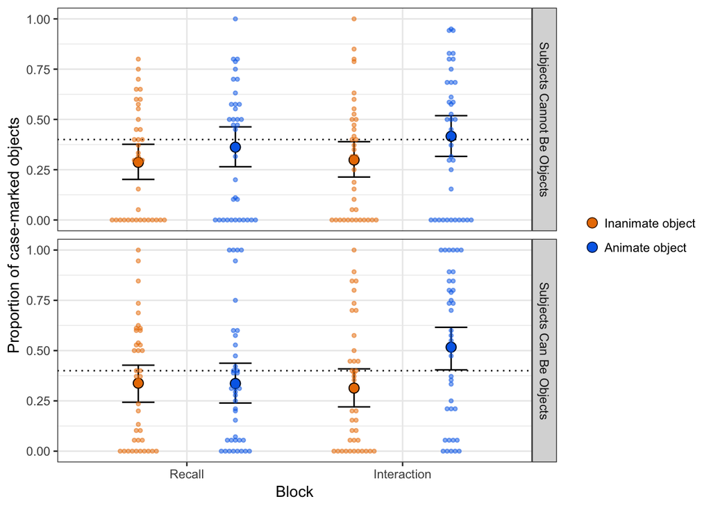

```r
ggplot(data=exp2.recall.vs.interaction.summary, aes(x=Block, y=casemarked,
                                                    colour=Animacy, fill=Animacy)) +
  facet_grid(EventType~.) +
  #points and CIs for casemarking by animacy
  stat_summary(geom='errorbar', fun.data='mean_cl_boot',fun.ymin="min", fun.ymax="max",width=0.3,position=position_dodge(0.9),color='black') +
  stat_summary(geom='point', fun.y='mean', position=position_dodge(0.9),size=3) +
  stat_summary(geom='point', fun.y='mean', position=position_dodge(0.9),size=3,
               shape=1,colour='black') +



  #horizontal line showing input
  geom_hline(yintercept=0.4,linetype=3) +
  #by-participant data
  geom_dotplot(aes(x=Block, y=casemarked, shape=Animacy),binaxis = "y", stackdir = "center",alpha=0.5,dotsize=2,position=position_dodge(0.9),binpositions='all',binwidth=1/100) +
  #then various axis/legend stuff
  xlab("Block") +
  theme_bw() +
  ylab("Proportion of case-marked objects") +
  theme(legend.title=element_blank()) +
  scale_colour_manual(values=my.colours[2:3],breaks=c("FALSE", "TRUE"),labels=c("Inanimate object", "Animate object")) +
  scale_fill_manual(values=my.colours[2:3],breaks=c("FALSE", "TRUE"),labels=c("Inanimate object", "Animate object")) +
  ggsave("../Figures/exp2-interaction-casemarking.pdf",width=9, height=6)
```

Stat where block is treatment-coded.

```r
exp2RecallVsInteractionData$Animacy <- factor(exp2RecallVsInteractionData$Animacy)
contrasts(exp2RecallVsInteractionData$Animacy) <- c(-0.5,0.5)
contrasts(exp2RecallVsInteractionData$EventType) <- c(-0.5,0.5)


exp2.recall.vs.interaction.model.1 <- glmer(casemarked ~ Animacy * Block * EventType + (1 + Animacy *  Block | workerId),data=exp2RecallVsInteractionData,family=binomial,control=glmerControl(optimizer="bobyqa"))
```

```r
summary(exp2.recall.vs.interaction.model.1)
```

```
## Generalized linear mixed model fit by maximum likelihood (Laplace Approximation) ['glmerMod']
##  Family: binomial  ( logit )
## Formula: casemarked ~ Animacy * Block * EventType + (1 + Animacy * Block |      workerId)
##    Data: exp2RecallVsInteractionData
## Control: glmerControl(optimizer = "bobyqa")
##
##      AIC      BIC   logLik deviance df.resid
##   5245.7   5365.6  -2604.8   5209.7     5766
##
## Scaled residuals:
##     Min      1Q  Median      3Q     Max
## -3.9229 -0.5558 -0.1001  0.5489  5.4336
##
## Random effects:
##  Groups   Name                      Variance Std.Dev. Corr
##  workerId (Intercept)               5.7607   2.4001
##           Animacy1                  3.3090   1.8191    0.14
##           BlockInteraction          1.5981   1.2642   -0.18  0.10
##           Animacy1:BlockInteraction 0.9846   0.9923   -0.41  0.18  0.34
## Number of obs: 5784, groups:  workerId, 77
##
## Fixed effects:
##                                      Estimate Std. Error z value Pr(>|z|)
## (Intercept)                           -1.5675     0.2891  -5.423 5.88e-08 ***
## Animacy1                               0.2993     0.2711   1.104  0.26953
## BlockInteraction                       0.3627     0.1896   1.913  0.05572 .
## EventType1                             0.4411     0.5694   0.775  0.43853
## Animacy1:BlockInteraction              0.9802     0.2549   3.846  0.00012 ***
## Animacy1:EventType1                   -0.2445     0.4929  -0.496  0.61977
## BlockInteraction:EventType1            0.3453     0.3512   0.983  0.32551
## Animacy1:BlockInteraction:EventType1   1.0716     0.4110   2.607  0.00913 **
## ---
## Signif. codes:  0 '***' 0.001 '**' 0.01 '*' 0.05 '.' 0.1 ' ' 1
##
## Correlation of Fixed Effects:
##             (Intr) Anmcy1 BlckIn EvntT1 An1:BI A1:ET1 BI:ET1
## Animacy1     0.084
## BlckIntrctn -0.277  0.072
## EventType1  -0.037  0.002  0.034
## Anmcy1:BlcI -0.161 -0.323  0.020 -0.002
## Anmcy1:EvT1  0.001 -0.086 -0.002  0.111  0.062
## BlckInt:ET1  0.036  0.001 -0.092 -0.248  0.005  0.056
## Anm1:BI:ET1  0.009  0.069  0.006 -0.228 -0.137 -0.176  0.179
```

```r
exp2.recall.vs.interaction.model.cannot <- glmer(casemarked ~ Block * Animacy  + (1 + Block * Animacy | workerId),data=subset(exp2RecallVsInteractionData,EventType=="Subjects Cannot Be Objects"), family=binomial,control=glmerControl(optimizer="bobyqa"))
```

```
## boundary (singular) fit: see ?isSingular
```

```r
exp2.recall.vs.interaction.model.can <- glmer(casemarked ~ Block * Animacy  + (1 + Block * Animacy | workerId),data=subset(exp2RecallVsInteractionData, EventType=="Subjects Can Be Objects"), family=binomial,control=glmerControl(optimizer="bobyqa"))
```

```r
summary(exp2.recall.vs.interaction.model.cannot)
```

```
## Generalized linear mixed model fit by maximum likelihood (Laplace Approximation) ['glmerMod']
##  Family: binomial  ( logit )
## Formula: casemarked ~ Block * Animacy + (1 + Block * Animacy | workerId)
##    Data: subset(exp2RecallVsInteractionData, EventType == "Subjects Cannot Be Objects")
## Control: glmerControl(optimizer = "bobyqa")
##
##      AIC      BIC   logLik deviance df.resid
##   2566.8   2650.0  -1269.4   2538.8     2814
##
## Scaled residuals:
##     Min      1Q  Median      3Q     Max
## -3.8096 -0.5952 -0.0838  0.6059  4.0208
##
## Random effects:
##  Groups   Name                      Variance Std.Dev. Corr
##  workerId (Intercept)               7.3641   2.7137
##           BlockInteraction          1.0720   1.0354   -0.21
##           Animacy1                  0.3969   0.6300   -0.19  0.28
##           BlockInteraction:Animacy1 0.2293   0.4789   -0.12 -0.36  0.79
## Number of obs: 2828, groups:  workerId, 38
##
## Fixed effects:
##                           Estimate Std. Error z value Pr(>|z|)
## (Intercept)                -1.8244     0.4737  -3.851 0.000118 ***
## BlockInteraction            0.2687     0.2731   0.984 0.325169
## Animacy1                    0.5913     0.3006   1.967 0.049191 *
## BlockInteraction:Animacy1   0.3104     0.3783   0.821 0.411877
## ---
## Signif. codes:  0 '***' 0.001 '**' 0.01 '*' 0.05 '.' 0.1 ' ' 1
##
## Correlation of Fixed Effects:
##             (Intr) BlckIn Anmcy1
## BlckIntrctn -0.326
## Animacy1    -0.156  0.218
## BlckIntr:A1  0.045 -0.280 -0.586
## convergence code: 0
## boundary (singular) fit: see ?isSingular
```

```r
summary(exp2.recall.vs.interaction.model.can)
```

```
## Generalized linear mixed model fit by maximum likelihood (Laplace Approximation) ['glmerMod']
##  Family: binomial  ( logit )
## Formula: casemarked ~ Block * Animacy + (1 + Block * Animacy | workerId)
##    Data: subset(exp2RecallVsInteractionData, EventType == "Subjects Can Be Objects")
## Control: glmerControl(optimizer = "bobyqa")
##
##      AIC      BIC   logLik deviance df.resid
##   2657.9   2741.8  -1315.0   2629.9     2942
##
## Scaled residuals:
##     Min      1Q  Median      3Q     Max
## -3.5751 -0.5161 -0.1320  0.4929  5.1122
##
## Random effects:
##  Groups   Name                      Variance Std.Dev. Corr
##  workerId (Intercept)               4.633    2.152
##           BlockInteraction          2.093    1.447    -0.25
##           Animacy1                  7.554    2.748     0.19  0.05
##           BlockInteraction:Animacy1 2.515    1.586    -0.46  0.49  0.00
## Number of obs: 2956, groups:  workerId, 39
##
## Fixed effects:
##                           Estimate Std. Error z value Pr(>|z|)
## (Intercept)                -1.3538     0.3624  -3.736 0.000187 ***
## BlockInteraction            0.5388     0.2790   1.931 0.053483 .
## Animacy1                    0.1760     0.4926   0.357 0.720795
## BlockInteraction:Animacy1   1.6484     0.3946   4.178 2.95e-05 ***
## ---
## Signif. codes:  0 '***' 0.001 '**' 0.01 '*' 0.05 '.' 0.1 ' ' 1
##
## Correlation of Fixed Effects:
##             (Intr) BlckIn Anmcy1
## BlckIntrctn -0.313
## Animacy1     0.163  0.032
## BlckIntr:A1 -0.289  0.217 -0.221
```

# Exp 1 + 2 combined analysis

```r
exp1Data <- read.csv('../RawData/exp1Data.csv')

exp1Data$Day <- as.factor(exp1Data$Day)

exp1Data$EventType <- revalue(exp1Data$EventType,
                              c("Agents Cannot Be Patients"="Subjects Cannot Be Objects",
                                "Agents Can Be Patients"="Subjects Can Be Objects"))
exp1Data$EventType <- relevel(as.factor(exp1Data$EventType),
                                        ref='Subjects Cannot Be Objects')
#needs to be factor to merge with exp1Data
exp1Data$Animacy <- as.factor(exp1Data$Animacy)

exp1And2Data <- bind_rows(exp2Data,exp1Data)
exp1And2Data$Experiment <- as.factor(exp1And2Data$Experiment)
```

## The effect of animacy on casemarking

Does it differ between experiments?

```r
#Run stat
exp1And2Data$Animacy <- as.factor(exp1And2Data$Animacy)
contrasts(exp1And2Data$Animacy) <- c(-0.5,0.5)
exp1And2Data$EventType <- as.factor(exp1And2Data$EventType)
contrasts(exp1And2Data$EventType) <- c(-0.5,0.5)
contrasts(exp1And2Data$Experiment) <- c(-0.5,0.5) #coding Exp2 as positive
```

```r
exp1and2.case.marking.model.1 <- glmer(casemarked ~ Experiment * Animacy * EventType * Day + (1 + Animacy * Day | workerId),data=subset(exp1And2Data,Block=="SentenceTest1" & grammatical),family=binomial,control=glmerControl(optimizer="bobyqa"))
summary(exp1and2.case.marking.model.1)
```

```
## Generalized linear mixed model fit by maximum likelihood (Laplace Approximation) ['glmerMod']
##  Family: binomial  ( logit )
## Formula: casemarked ~ Experiment * Animacy * EventType * Day + (1 + Animacy *      Day | workerId)
##    Data: subset(exp1And2Data, Block == "SentenceTest1" & grammatical)
## Control: glmerControl(optimizer = "bobyqa")
##
##      AIC      BIC   logLik deviance df.resid
##  17000.6  17354.4  -8455.3  16910.6    19151
##
## Scaled residuals:
##     Min      1Q  Median      3Q     Max
## -5.5773 -0.4682 -0.0662  0.5067  7.6388
##
## Random effects:
##  Groups   Name          Variance Std.Dev. Corr
##  workerId (Intercept)   6.917    2.630
##           Animacy1      2.467    1.571    -0.05
##           Day3          2.362    1.537    -0.34  0.08
##           Day4          3.997    1.999    -0.36 -0.03  0.73
##           Animacy1:Day3 2.354    1.534    -0.14 -0.33 -0.13  0.04
##           Animacy1:Day4 1.852    1.361     0.03 -0.32 -0.18  0.05  0.89
## Number of obs: 19196, groups:  workerId, 198
##
## Fixed effects:
##                                      Estimate Std. Error z value Pr(>|z|)
## (Intercept)                          -0.70096    0.19969  -3.510 0.000448 ***
## Experiment1                          -2.36472    0.39665  -5.962  2.5e-09 ***
## Animacy1                             -0.06023    0.15227  -0.396 0.692450
## EventType1                           -0.21813    0.39468  -0.553 0.580481
## Day3                                  0.30416    0.13750   2.212 0.026968 *
## Day4                                  0.37474    0.17265   2.171 0.029962 *
## Experiment1:Animacy1                  0.71839    0.30159   2.382 0.017219 *
## Experiment1:EventType1               -0.14855    0.77445  -0.192 0.847887
## Animacy1:EventType1                   0.04382    0.29216   0.150 0.880774
## Experiment1:Day3                      0.02544    0.27484   0.093 0.926246
## Experiment1:Day4                     -0.20484    0.34583  -0.592 0.553644
## Animacy1:Day3                         0.18103    0.17386   1.041 0.297791
## Animacy1:Day4                         0.34963    0.16785   2.083 0.037247 *
## EventType1:Day3                       0.22085    0.26921   0.820 0.412022
## EventType1:Day4                       0.75314    0.34092   2.209 0.027166 *
## Experiment1:Animacy1:EventType1       0.05397    0.57837   0.093 0.925659
## Experiment1:Animacy1:Day3             0.04066    0.34978   0.116 0.907449
## Experiment1:Animacy1:Day4            -0.66732    0.34543  -1.932 0.053375 .
## Experiment1:EventType1:Day3          -0.52867    0.53272  -0.992 0.321007
## Experiment1:EventType1:Day4           0.39001    0.67158   0.581 0.561422
## Animacy1:EventType1:Day3             -0.16621    0.33224  -0.500 0.616897
## Animacy1:EventType1:Day4             -0.18573    0.32157  -0.578 0.563557
## Experiment1:Animacy1:EventType1:Day3 -0.02153    0.65023  -0.033 0.973584
## Experiment1:Animacy1:EventType1:Day4 -0.29237    0.62607  -0.467 0.640504
## ---
## Signif. codes:  0 '***' 0.001 '**' 0.01 '*' 0.05 '.' 0.1 ' ' 1
```

```
##
## Correlation matrix not shown by default, as p = 24 > 12.
## Use print(x, correlation=TRUE)  or
##     vcov(x)        if you need it
```

```
## convergence code: 0
## maxfun < 10 * length(par)^2 is not recommended.
```

Same model controlling for word order.

Full model fails to converge.

```r
contrasts(exp1And2Data$WordOrder) <- c(-0.5,0.5)
exp1and2.case.marking.model.2 <- glmer(casemarked ~ Experiment * Animacy * Day
                                       * (WordOrder + EventType)
                                       + (1 | workerId)
                                       + (0 + Animacy * Day * WordOrder | workerId),
                                       data=subset(exp1And2Data,Block=="SentenceTest1" & grammatical),
                                       family=binomial,control=glmerControl(optimizer="bobyqa"))
```

```
## boundary (singular) fit: see ?isSingular
```

Simplifying: pulling out 3-way. Still fails to converge.

```r
exp1and2.case.marking.model.3 <- glmer(casemarked ~ Experiment * Animacy * Day
                                       * (WordOrder + EventType)
                                       + (1 | workerId)
                                       + (0 + Animacy * Day * WordOrder
                                          - Animacy:Day:WordOrder
                                          | workerId),
                                       data=subset(exp1And2Data,Block=="SentenceTest1" & grammatical),family=binomial,control=glmerControl(optimizer="bobyqa"))
```

Simplifying again: try pulling out 2-ways involving Day. Two ways ot do this, trying them both. Model 4 converges, shows same pattern as simpler analysis.

```r
exp1and2.case.marking.model.4 <- glmer(casemarked ~ Experiment * Animacy * Day
                                       * (WordOrder + EventType)
                                       + (1 | workerId)
                                       + (0 + Animacy * Day * WordOrder
                                          - Animacy:Day:WordOrder
                                          - Animacy:Day | workerId),
                                       data=subset(exp1And2Data,Block=="SentenceTest1" & grammatical),family=binomial,control=glmerControl(optimizer="bobyqa"))
exp1and2.case.marking.model.5 <- glmer(casemarked ~ Experiment * Animacy * Day
                                       * (WordOrder + EventType)
                                       + (1 | workerId)
                                       + (0 + Animacy * Day * WordOrder
                                          - Animacy:Day:WordOrder
                                          - Animacy:WordOrder | workerId),
                                       data=subset(exp1And2Data,Block=="SentenceTest1" & grammatical),family=binomial,control=glmerControl(optimizer="bobyqa"))
```

Several VIFs above 3.

```r
summary(exp1and2.case.marking.model.4)
```

```
## Generalized linear mixed model fit by maximum likelihood (Laplace Approximation) ['glmerMod']
##  Family: binomial  ( logit )
## Formula: casemarked ~ Experiment * Animacy * Day * (WordOrder + EventType) +      (1 | workerId) + (0 + Animacy * Day * WordOrder - Animacy:Day:WordOrder -      Animacy:Day | workerId)
##    Data: subset(exp1And2Data, Block == "SentenceTest1" & grammatical)
## Control: glmerControl(optimizer = "bobyqa")
##
##      AIC      BIC   logLik deviance df.resid
##  15985.2  16559.2  -7919.6  15839.2    19123
##
## Scaled residuals:
##     Min      1Q  Median      3Q     Max
## -7.4154 -0.4024 -0.0531  0.4102  7.1969
##
## Random effects:
##  Groups     Name                Variance Std.Dev. Corr
##  workerId   (Intercept)         2.761    1.662
##  workerId.1 AnimacyFALSE        5.888    2.427
##             AnimacyTRUE         6.085    2.467     0.81
##             Day3                2.220    1.490    -0.64 -0.64
##             Day4                3.832    1.958    -0.62 -0.61  0.80
##             WordOrder1          6.798    2.607    -0.20 -0.23  0.18  0.08
##             Animacy1:WordOrder1 2.086    1.444     0.06  0.10  0.04 -0.08  0.14
##             Day3:WordOrder1     7.906    2.812     0.36  0.29 -0.04  0.02 -0.79  0.07
##             Day4:WordOrder1     7.725    2.779     0.33  0.29 -0.01  0.06 -0.78  0.08  0.93
## Number of obs: 19196, groups:  workerId, 198
##
## Fixed effects:
##                                       Estimate Std. Error z value Pr(>|z|)
## (Intercept)                          -0.382164   0.229919  -1.662 0.096479 .
## Experiment1                          -1.814930   0.456931  -3.972 7.13e-05 ***
## Animacy1                             -0.236901   0.164884  -1.437 0.150781
## Day3                                  0.285332   0.157258   1.814 0.069612 .
## Day4                                  0.283649   0.190416   1.490 0.136322
## WordOrder1                           -1.055371   0.272595  -3.872 0.000108 ***
## EventType1                           -0.304799   0.439513  -0.693 0.488000
## Experiment1:Animacy1                  0.666647   0.327547   2.035 0.041824 *
## Experiment1:Day3                      0.277427   0.310390   0.894 0.371429
## Experiment1:Day4                     -0.160819   0.375575  -0.428 0.668510
## Animacy1:Day3                         0.140283   0.141557   0.991 0.321687
## Animacy1:Day4                         0.362907   0.145635   2.492 0.012706 *
```

[output cut: 11 more lines]

```
## Experiment1:Animacy1:EventType1       0.271639   0.582663   0.466 0.641071
## Experiment1:Day3:WordOrder1          -0.490098   0.592647  -0.827 0.408257
## Experiment1:Day4:WordOrder1          -0.175942   0.608842  -0.289 0.772598
## Experiment1:Day3:EventType1          -0.274435   0.560894  -0.489 0.624642
## Experiment1:Day4:EventType1           0.484638   0.704018   0.688 0.491208
## Animacy1:Day3:WordOrder1             -0.131973   0.283316  -0.466 0.641347
## Animacy1:Day4:WordOrder1             -0.219565   0.291973  -0.752 0.452049
## Animacy1:Day3:EventType1             -0.161912   0.227650  -0.711 0.476942
## Animacy1:Day4:EventType1             -0.240049   0.238303  -1.007 0.313778
## Experiment1:Animacy1:Day3:WordOrder1 -1.210777   0.562228  -2.154 0.031277 *
## Experiment1:Animacy1:Day4:WordOrder1 -0.079658   0.580042  -0.137 0.890768
## Experiment1:Animacy1:Day3:EventType1 -0.269001   0.453349  -0.593 0.552938
## Experiment1:Animacy1:Day4:EventType1 -0.420427   0.474459  -0.886 0.375554
## ---
## Signif. codes:  0 '***' 0.001 '**' 0.01 '*' 0.05 '.' 0.1 ' ' 1
```

```
##
## Correlation matrix not shown by default, as p = 36 > 12.
## Use print(x, correlation=TRUE)  or
##     vcov(x)        if you need it
```

```
## convergence code: 0
## maxfun < 10 * length(par)^2 is not recommended.
```

```r
car::vif(exp1and2.case.marking.model.4)
```

```
##                                      GVIF Df GVIF^(1/(2*Df))
## Experiment                       1.732950  1        1.316415
## Animacy                          1.678796  1        1.295683
## Day                              1.358411  2        1.079587
## WordOrder                        3.475884  1        1.864372
## EventType                        1.511812  1        1.229557
## Experiment:Animacy               1.665467  1        1.290530
## Experiment:Day                   1.923175  2        1.177619
## Animacy:Day                      2.709577  2        1.282996
## Experiment:WordOrder             3.439107  1        1.854483
## Experiment:EventType             1.494246  1        1.222394
## Animacy:WordOrder                2.349935  1        1.532950
## Animacy:EventType                1.318344  1        1.148192
## Day:WordOrder                    3.765382  2        1.393004
## Day:EventType                    1.539948  2        1.113978
## Experiment:Animacy:Day           2.643647  2        1.275119
## Experiment:Animacy:WordOrder     2.359951  1        1.536213
## Experiment:Animacy:EventType     1.324359  1        1.150808
## Experiment:Day:WordOrder         3.695116  2        1.386459
## Experiment:Day:EventType         1.518858  2        1.110144
## Animacy:Day:WordOrder            3.507406  2        1.368505
## Animacy:Day:EventType            1.350090  2        1.077930
## Experiment:Animacy:Day:WordOrder 3.460950  2        1.363951
## Experiment:Animacy:Day:EventType 1.356758  2        1.079259
```

## Recall vs interaction

```r
exp1And2RecallVsInteractionData <- subset(exp1And2Data,(Block=="Interaction" | Block=="SentenceTest1") & grammatical & Day==4)
exp1And2RecallVsInteractionData <- droplevels(exp1And2RecallVsInteractionData)

contrasts(exp1And2RecallVsInteractionData$Experiment) <- c(-0.5,0.5) #don't really care about this one

contrasts(exp1And2RecallVsInteractionData$Animacy) <- c(-0.5,0.5)

contrasts(exp1And2RecallVsInteractionData$EventType) <- c(-0.5,0.5)

#set SentenceTest1 to reference level
exp1And2RecallVsInteractionData$Block <- relevel(exp1And2RecallVsInteractionData$Block,
                                                 ref="SentenceTest1")
```

```r
exp1And2.recall.vs.interaction.model.1 <- glmer(casemarked ~ Animacy * Block * EventType * Experiment + (1 + Animacy *  Block | workerId),data=exp1And2RecallVsInteractionData,family=binomial,control=glmerControl(optimizer="bobyqa"))
```

```r
summary(exp1And2.recall.vs.interaction.model.1)
```

```
## Generalized linear mixed model fit by maximum likelihood (Laplace Approximation) ['glmerMod']
##  Family: binomial  ( logit )
## Formula: casemarked ~ Animacy * Block * EventType * Experiment + (1 +      Animacy * Block | workerId)
##    Data: exp1And2RecallVsInteractionData
## Control: glmerControl(optimizer = "bobyqa")
##
##      AIC      BIC   logLik deviance df.resid
##  10556.1  10749.6  -5252.1  10504.1    12573
##
## Scaled residuals:
##     Min      1Q  Median      3Q     Max
## -6.3706 -0.3368  0.0680  0.4694  5.0425
##
## Random effects:
##  Groups   Name                      Variance Std.Dev. Corr
##  workerId (Intercept)               7.5297   2.7440
##           Animacy1                  2.8730   1.6950   -0.03
##           BlockInteraction          2.4809   1.5751   -0.24 -0.19
##           Animacy1:BlockInteraction 0.7743   0.8799   -0.34  0.23  0.29
## Number of obs: 12599, groups:  workerId, 169
##
## Fixed effects:
##                                                  Estimate Std. Error z value Pr(>|z|)
## (Intercept)                                      -0.39014    0.21987  -1.774   0.0760 .
## Animacy1                                          0.33769    0.16147   2.091   0.0365 *
## BlockInteraction                                  0.65469    0.14356   4.560 5.11e-06 ***
## EventType1                                        0.51857    0.43773   1.185   0.2361
## Experiment1                                      -2.51799    0.43944  -5.730 1.00e-08 ***
## Animacy1:BlockInteraction                         0.67333    0.13972   4.819 1.44e-06 ***
## Animacy1:EventType1                              -0.13995    0.31831  -0.440   0.6602
## BlockInteraction:EventType1                       0.19305    0.28646   0.674   0.5004
## Animacy1:Experiment1                              0.22866    0.33115   0.690   0.4899
## BlockInteraction:Experiment1                     -0.58687    0.29418  -1.995   0.0460 *
## EventType1:Experiment1                            0.04472    0.86192   0.052   0.9586
## Animacy1:BlockInteraction:EventType1              0.64107    0.27675   2.316   0.0205 *
## Animacy1:BlockInteraction:Experiment1             0.50822    0.31708   1.603   0.1090
## Animacy1:EventType1:Experiment1                  -0.43572    0.62408  -0.698   0.4851
## BlockInteraction:EventType1:Experiment1           0.12238    0.56382   0.217   0.8282
## Animacy1:BlockInteraction:EventType1:Experiment1  0.90311    0.53408   1.691   0.0908 .
## ---
## Signif. codes:  0 '***' 0.001 '**' 0.01 '*' 0.05 '.' 0.1 ' ' 1
```

```
##
## Correlation matrix not shown by default, as p = 16 > 12.
## Use print(x, correlation=TRUE)  or
##     vcov(x)        if you need it
```